# Project One

# Section 1

## This dataset is a package in R Studio called “dragracer” that was found after searching the internet for data sets on what is arguably the greatest television show ever invented, RuPaul’s Drag Race. There are three tables in this dataset of varying length and detail. All datasets include the contestants of the show and the season they competed on. This dataset does not include information from spin-off shows like RuPaul’s Drag Race All Stars or any of the international versions like RuPaul’s Drag Race UK or Canada’s Drag Race. There are small amounts of errors or inconsistencies in these datasets, including a misspelled name and missing values for runway themes. As a person whose knowledge on the show far exceeds his ability of data analysis, I did not learn much from these datasets, with the exception being the lack of repeated “older” winners.

# Section 2

## Loading of Packages

```r
library(ggplot2) #Loading packages
library(dplyr)
library(tidyverse)
library(dragracer)

data(package = "dragracer")

rpdr_contep <- rpdr_contep #Assigns tables to objects
rpdr_contest <- rpdr_contestants
rpdr_ep <- rpdr_ep
```

## Visual 1

### Here, we see a visual that represents the amount of times a lipsync artist was performed. As we can see, the host of the show, RuPaul, has been performed in the Lipsync For Your Life more than any other artist. What is surprising about this is that the record for the most lipsynced artist was Paula Abdul as far as season 6, which suggests that as the show continues to evolve and grow, they are spending more money on licenses for other, more successful artists.

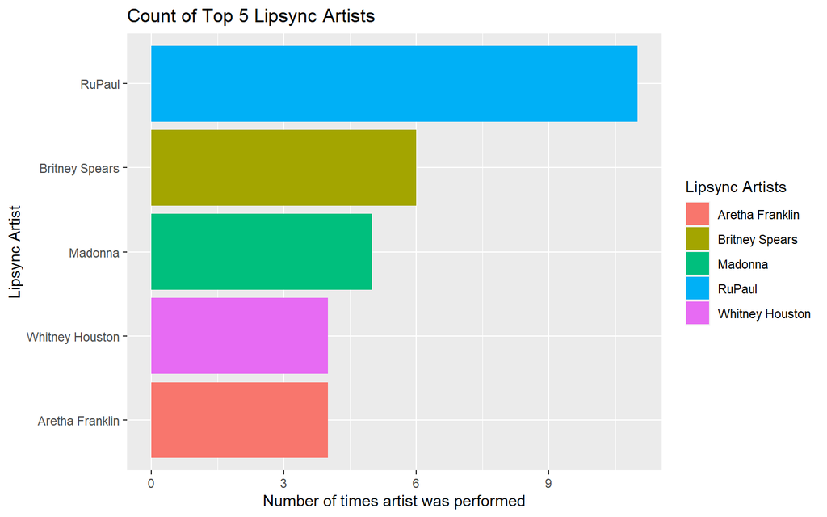

```r
artists <- rpdr_ep %>% #Assigns the rpdr_ep dataset to new variable
  select(lipsyncartist) %>% #selects lipsync artists
  drop_na() %>%  #Drops NA values
  add_count(lipsyncartist,name="Counts") %>% #Adds column of count of values
  arrange(desc(Counts)) %>% #Arranges descending based on count of values
  distinct(lipsyncartist,Counts) %>% #Selects distinct artists and counts
  head(5) #Selects top 5


artists %>% #Calls the variable made in first line in previous chunk
  ggplot(aes(x=reorder(lipsyncartist,Counts),y=Counts,fill=lipsyncartist)) + #Plots lipsync artists and their counts
  coord_flip() + #Flips orientation of graph
  geom_bar(stat="identity") +
  labs(title="Count of Top 5 Lipsync Artists",x="Lipsync Artist",y="Number of times artist was performed",fill="Lipsync Artists")
```

## Visual 2

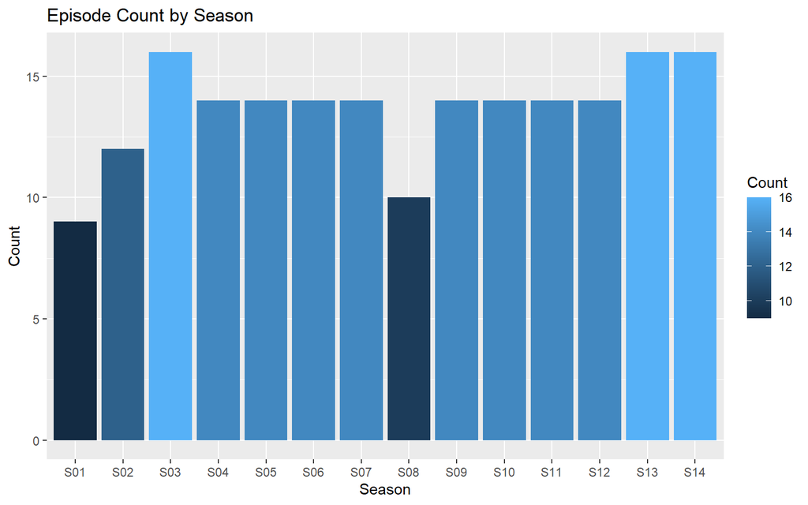

```r
#episode count by season

episodecount <- rpdr_ep %>% #Assigns rpdr_ep table to new variable
  group_by(season) %>% #Groups table by season column
  summarise(count=n()) #Counts number of rows

episodecount %>% #Calls variable made in previous chunk
  ggplot(aes(x=season,y=count,fill=count)) + #Fill on count to clarify highest counts rows when grouped by season (episodes)
  geom_bar(stat="identity") +
  labs(title="Episode Count by Season",x="Season",y="Count",fill="Count")
```

## Visual 3

### Here we see the age of winners by season. I used a line graph here and kept the x-axis in line with seasons to show that if an older (than 30) contestant wins one season, a younger contestant will most likely win the next season. It also shows that there have only been three winners of the show above the age of 30.

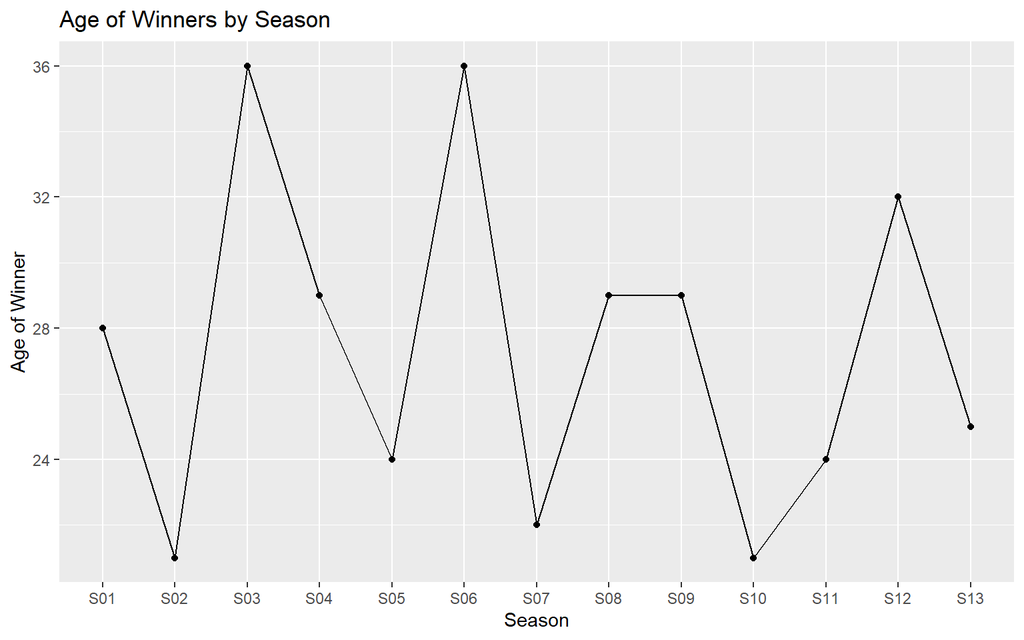

```r
winners <- rpdr_contep %>% #Assigns table to new variable
  filter(rank==1) %>% #Filters table for only rows where rank is equal to 1
  distinct(contestant) #Selects only distinct contestants

winners <- c("BeBe Zahara Benet","Tyra Sanchez","Raja","Sharon Needles","Jinkx Monsoon","Bianca Del Rio","Violet Chachki","Bob the Drag Queen","Sasha Velour","Aquaria","Yvie Oddly","Jaida Essence Hall","Symone") #Creates vector of String values based on output from previous chunk

rpdr_contestants %>%
  mutate(winner_check = ifelse(contestant %in% winners, "Winner","Not Winner")) %>% #Adds column winner_check
  filter(winner_check=="Winner") %>% #Filters based on if/else results
  ggplot(aes(x=season,y=age)) +
  geom_line(aes(group=1)) + geom_point() + #Adds points to line graph for values
  labs(title="Age of Winners by Season",x="Season",y="Age of Winner")
```

## Visual 4

### This visualizes the amount of winners by hometown. As we can see, all but three winners have come from different hometowns. This suggests that contestants from Brooklyn, New York have the best chance of winning this show.

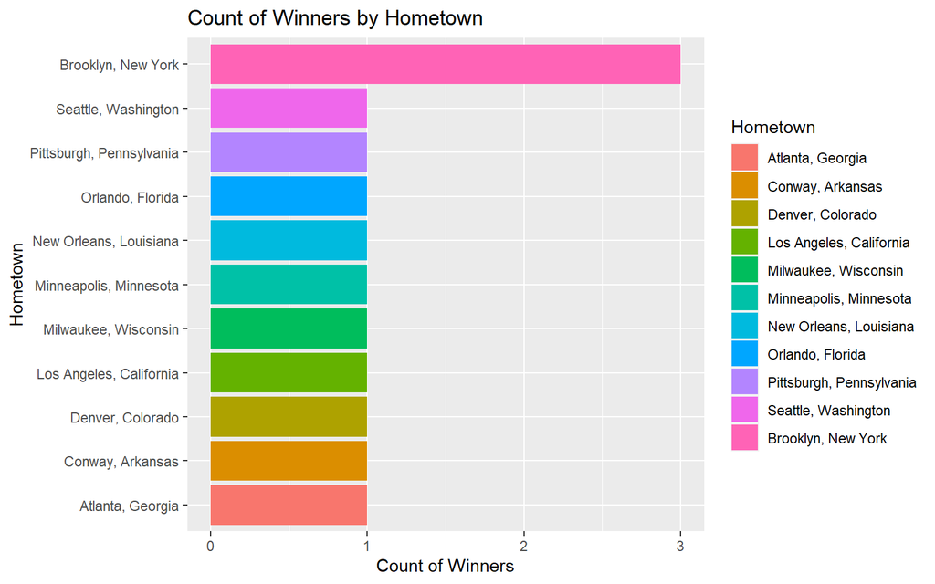

```r
rpdr_contestants %>%
  mutate(winner_check = ifelse(contestant %in% winners, "Winner","Not Winner")) %>% #Adds column with values based on if the values in the vector object "winners" is equal to values in the "contestant" column
  filter(winner_check=="Winner") %>% #Filters by new column
  group_by(hometown) %>% #Groups set by hometown
  count() %>% #Counts values
  ggplot(aes(x=reorder(hometown,n), y = n, fill= reorder(hometown,n))) + #Plots on graph in order of the count of hometowns
  geom_col() +
  labs(title="Count of Winners by Hometown",x="Hometown",y="Count of Winners",fill="Hometown") +
  coord_flip() #Flips graph
```

## Visual 5

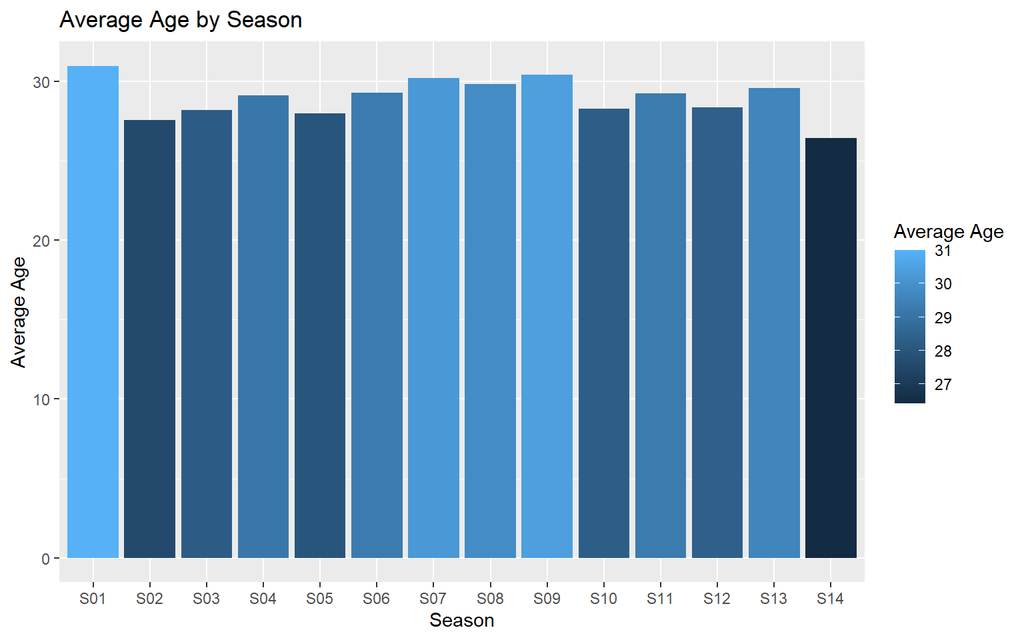

```r
rpdr_contestants %>%
  group_by(season) %>% #Groups by season
  summarise_at(vars(age), list(age_avg = mean)) %>% #Creates list of average ages
  ggplot(aes(x=season,y=age_avg,fill=age_avg)) +
  geom_bar(stat="identity") +
  labs(title="Average Age by Season",x="Season",y="Average Age",fill="Average Age")
```

## Visual 6

### This graph shows us the ranks of the 5 oldest contestants. As we can see, Darienne Lake performed the best on her season compared to the other four oldest contestants. What is interesting is that Darienne Lake finished in fourth place on her season in Season 6, and no older contestant has been able to come close to that rank since. Tamisha Iman, the most recent contestant to compete on the show in Season 13, finished at a measly 11th place.

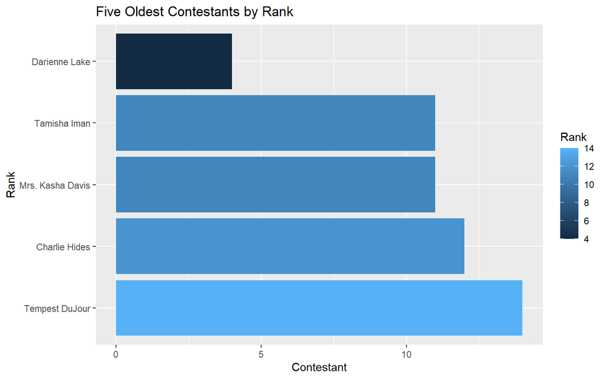

```r
#rpdr_contestants %>%
#  arrange(desc(age)) %>% #Arranges data based on age, oldest to youngest
#  head(5) #Produces top 5 oldest contestants to create vector below

oldheads <- c("Charlie Hides","Tamisha Iman","Tempest DuJour","Mrs. Kasha Davis","Darienne Lake")


rpdr_contep %>%
  mutate(oldcheck = ifelse(contestant %in% oldheads, "Old Head","Not Old Head")) %>% #Creates column where the values are based on whether or not the contestant is included on the vector object "oldheads"
  filter(oldcheck == "Old Head") %>%
  distinct(contestant,rank,season) %>% #Removes duplicate values
  group_by(contestant,rank,season) %>%
  count() %>%
  ggplot(aes(x=reorder(contestant,-rank),y=rank,fill=rank)) + #Reorders contestants based on descending rank
  geom_bar(stat="identity") +
  coord_flip() +
  labs(x="Rank",y="Contestant",fill="Rank",title="Five Oldest Contestants by Rank")
```

## Visual 7

### This visual shows us the distributions of age by season. We can also see outliers in these sets, where the contestants included people who were much younger or much older than the rest of the cast. We can see clearly that Season 9 had the oldest contestant.

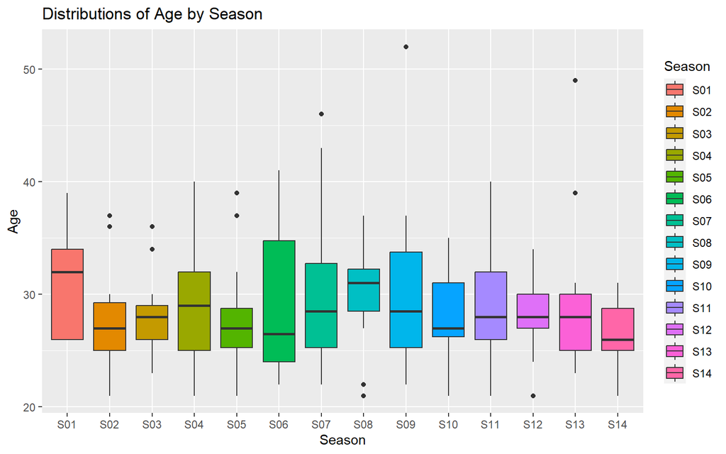

```r
rpdr_contestants %>%
  ggplot(aes(x=season,y=age, fill=season)) +
  geom_boxplot() + #Box plot was used to show distributions
  labs(title="Distributions of Age by Season",x="Season",y="Age",fill="Season")
```

# Section 3

### A statistician can certainly apply statistical methods to these datasets. For instance, someone may be able to predict the placement of a contestant on an episode (outcome/response/y) based on their placement(s) on the episode(s) prior (predictor/explanatory,x). Another case may be made to explore the possibility of predicting a contestant’s placement based on hometown.